# Weather Classification using Wide and Deep Neural Networks

Created by: Florian Hurlbert and Kimberly McNeil (Fall 2024)

Our Data Set: Weather Type Classification

Dateset Link: https://www.kaggle.com/datasets/nikhil7280/weather-type-classification

## Preparation

### Preprocessing

Define and prepare your class variables. Use proper variable representations (int, float, one-hot, etc.). Use pre-processing methods (as needed) for dimensionality reduction, scaling, etc. Remove variables that are not needed/useful for the analysis. Describe the final dataset that is used for classification/regression (include a description of any newly formed variables you created).

```python
# Import Needed Libraries
import pandas as pd
import numpy as np
import matplotlib.pyplot as plt
import seaborn as sns

from sklearn.model_selection import train_test_split
from sklearn.preprocessing import LabelEncoder
from sklearn.preprocessing import StandardScaler

le = LabelEncoder()
```

```python
import warnings
warnings.filterwarnings('ignore')
```

```python
from google.colab import drive
drive.mount('/content/drive')
```

```python
df = pd.read_csv('/content/drive/MyDrive/Fall 2024/Intro to Machine Learning/Projects/weather_classification_data.csv')
```

```python
df.head()
```

|  | Temperature | Humidity | Wind Speed | Precipitation (%) | Cloud Cover | Atmospheric Pressure | UV Index | Season | Visibility (km) | Location | Weather Type |
| --- | --- | --- | --- | --- | --- | --- | --- | --- | --- | --- | --- |
| 0 | 14.0 | 73 | 9.5 | 82.0 | partly cloudy | 1010.82 | 2 | Winter | 3.5 | inland | Rainy |
| 1 | 39.0 | 96 | 8.5 | 71.0 | partly cloudy | 1011.43 | 7 | Spring | 10.0 | inland | Cloudy |
| 2 | 30.0 | 64 | 7.0 | 16.0 | clear | 1018.72 | 5 | Spring | 5.5 | mountain | Sunny |
| 3 | 38.0 | 83 | 1.5 | 82.0 | clear | 1026.25 | 7 | Spring | 1.0 | coastal | Sunny |
| 4 | 27.0 | 74 | 17.0 | 66.0 | overcast | 990.67 | 1 | Winter | 2.5 | mountain | Rainy |

```python
# Make a deep copy to preserve the original dataframes
# This allows us to revert back to the original data if needed during preprocessing
# and prevents accidentally modifying the original data when we make changes
from copy import deepcopy
df_orig = deepcopy(df)
```

```python
def assess_dataset(df):
 """
 Perform initial assessment of a dataset
 """
 print("Basic Information:")
 print("-----------------")
 print(f"Number of rows: {len(df)}")
 print(f"Number of columns: {len(df.columns)}")

 print("\nMissing Values:")
 print("--------------")
 missing = df.isnull().sum()
 print(missing[missing > 0])

 print("\nData Types:")
 print("-----------")
 print(df.dtypes)

 print("\nCategorical Columns:")
 print("------------------")
 categorical_columns = df_orig.select_dtypes(include=['object']).columns
 for col in categorical_columns:
  n_unique = df[col].nunique()
  print(f"{col}: {n_unique} unique values")
```

```python
assess_dataset(df)
```

```
Basic Information:
-----------------
Number of rows: 13200
Number of columns: 11

Missing Values:
--------------
Series([], dtype: int64)

Data Types:
-----------
Temperature             float64
Humidity                  int64
Wind Speed              float64
Precipitation (%)       float64
Cloud Cover              object
Atmospheric Pressure    float64
UV Index                  int64
Season                   object
Visibility (km)         float64
Location                 object
Weather Type             object
dtype: object

Categorical Columns:
------------------
Cloud Cover: 4 unique values
Season: 4 unique values
Location: 3 unique values
Weather Type: 4 unique values
```

A few of the inputs are strings, so we have to one-hot encode them.

```python
# One hot encoding Categorical Variables
categorical_cols = ['Cloud Cover', 'Season', 'Location', 'Weather Type']
df_encoded = pd.get_dummies(df, columns=categorical_cols, prefix=categorical_cols)

df_encoded.head()
```

|  | Temperature | Humidity | Wind Speed | Precipitation (%) | Atmospheric Pressure | UV Index | Visibility (km) | Cloud Cover_clear | Cloud Cover_cloudy | Cloud Cover_overcast | ... | Season_Spring | Season_Summer | Season_Winter | Location_coastal | Location_inland | Location_mountain | Weather Type_Cloudy | Weather Type_Rainy | Weather Type_Snowy | Weather Type_Sunny |
| --- | --- | --- | --- | --- | --- | --- | --- | --- | --- | --- | --- | --- | --- | --- | --- | --- | --- | --- | --- | --- | --- |
| 0 | 14.0 | 73 | 9.5 | 82.0 | 1010.82 | 2 | 3.5 | False | False | False | ... | False | False | True | False | True | False | False | True | False | False |
| 1 | 39.0 | 96 | 8.5 | 71.0 | 1011.43 | 7 | 10.0 | False | False | False | ... | True | False | False | False | True | False | True | False | False | False |
| 2 | 30.0 | 64 | 7.0 | 16.0 | 1018.72 | 5 | 5.5 | True | False | False | ... | True | False | False | False | False | True | False | False | False | True |
| 3 | 38.0 | 83 | 1.5 | 82.0 | 1026.25 | 7 | 1.0 | True | False | False | ... | True | False | False | True | False | False | False | False | False | True |
| 4 | 27.0 | 74 | 17.0 | 66.0 | 990.67 | 1 | 2.5 | False | False | True | ... | False | False | True | False | False | True | False | True | False | False |

5 rows × 22 columns

```python
# Scaling the non-one-hot encoding Input Features
# (as that will result in a loss of sparsity, distorted relationships, and less intuitive interpretability)

# 1. Separate numerical and categorical features
numerical_features = ['Temperature', 'Humidity', 'Wind Speed', 'Precipitation (%)', 'Atmospheric Pressure', 'UV Index', 'Visibility (km)']
categorical_features = ['Cloud Cover_clear', 'Cloud Cover_cloudy', 'Cloud Cover_overcast', 'Cloud Cover_partly cloudy',
                'Season_Autumn', 'Season_Spring', 'Season_Summer', 'Season_Winter',
                'Location_coastal', 'Location_inland', 'Location_mountain']

X_numerical = df_encoded[numerical_features]
X_categorical = df_encoded[categorical_features]

# 2. Scale numerical features
scaler = StandardScaler()
X_numerical_scaled = scaler.fit_transform(X_numerical)

# Convert scaled data back to DataFrame
X_numerical_scaled = pd.DataFrame(X_numerical_scaled, columns=numerical_features, index=X_numerical.index)  # Keep original index

# 3. Recombine features
X = pd.concat([X_numerical_scaled, X_categorical], axis=1)
```

```python
y = df_encoded[['Weather Type_Cloudy', 'Weather Type_Rainy', 'Weather Type_Snowy', 'Weather Type_Sunny']]
```

There was no reason to remove any variables, as none of them are unnecessary. However, we did need to add a few variables for the one-hot encoding. For the variables broken apart into one-hot encoded subvariables, all but one are false, depending on which category an instance falls into

Now that all of the variables have been preprocessed, let’s break down each one.

### Crossed Groups

Identify groups of features in your data that should be combined into cross-product features. Provide a compelling justification for why these features should be crossed (or why some features should not be crossed).

There are many features that shouldn't be crossed, and they can fall into a few different categories:

1. Do not cross two features within the same one-hot coded group, as they are mutually exclusive.
2. Do not cross anything with the target feature (any of the four weather types), as you can't exactly predict your output variable with your output variable. That would invalidate our models.
3. Do not cross too many features, as that can lead to overfitting because of how specific the predictions will become.
4. Do not cross features that have little to no rational relationship, as whatever the result is would not be very beneficial for prediction purposes.

Cloud Cover and Precipitation can be crossed, as certain cloud types, such as overcast, are more associated with rain and snow, while clear skies are more associated with sunny weather.

```python
# Cloud Cover_clear and Percipitation (%)
df_encoded['clear_precip'] = df_encoded['Cloud Cover_clear'] * df_encoded['Precipitation (%)']

# Cloud Cover_cloudy and Precipitation (%)
df_encoded['cloudy_precip'] = df_encoded['Cloud Cover_cloudy'] * df_encoded['Precipitation (%)']

# Cloud Cover_overcast and Precipitation (%)
df_encoded['overcast_precip'] = df_encoded['Cloud Cover_overcast'] * df_encoded['Precipitation (%)']

# Cloud Cover_partly cloudy and Precipitation (%)
df_encoded['partly_cloudy_precip'] = df_encoded['Cloud Cover_partly cloudy'] * df_encoded['Precipitation (%)']
```

Temperature and Humidity can be crossed, providing a feature to demonstrate how hot it feels, as a higher humidity can result in the temperature feeling much hotter.

```python
# Temperature and Humidity
df_encoded['temp_humidity'] = df_encoded['Temperature'] * df_encoded['Humidity']
```

Wind Speed and Temperature can be crossed, providing further information about wind chill, which makes the temperature feel much colder.

```python
# Wind Speed and Temperature
df_encoded['wind_temp'] = df_encoded['Wind Speed'] * df_encoded['Temperature']
```

Location and Season can be crossed to give information about regional weather patterns that are vastly different from other areas experiencing the same season. For instance, coastal areas tend to have cooler summers due to the ocean stabilizing the temperature of nearby land.

```python
# Coastal and Spring
df_encoded['coastal_spring'] = df_encoded['Location_coastal'] * df_encoded['Season_Spring']

# Coastal and Summer
df_encoded['coastal_summer'] = df_encoded['Location_coastal'] * df_encoded['Season_Summer']

# Coastal and Autumn
df_encoded['coastal_autumn'] = df_encoded['Location_coastal'] * df_encoded['Season_Autumn']

# Coastal and Winter
df_encoded['coastal_winter'] = df_encoded['Location_coastal'] * df_encoded['Season_Winter']

# ~~~

# Inland and Spring
df_encoded['inland_spring'] = df_encoded['Location_inland'] * df_encoded['Season_Spring']

# Inland and Summer
df_encoded['inland_summer'] = df_encoded['Location_inland'] * df_encoded['Season_Summer']

# Inland and Autumn
df_encoded['inland_autumn'] = df_encoded['Location_inland'] * df_encoded['Season_Autumn']

# Inland and Winter
df_encoded['inland_winter'] = df_encoded['Location_inland'] * df_encoded['Season_Winter']

# ~~~

# Mountain and Spring
df_encoded['mountain_spring'] = df_encoded['Location_mountain'] * df_encoded['Season_Spring']

# Mountain and Summer
df_encoded['mountain_summer'] = df_encoded['Location_mountain'] * df_encoded['Season_Summer']

# Mountain and Autumn
df_encoded['mountain_autumn'] = df_encoded['Location_mountain'] * df_encoded['Season_Autumn']

# Mountain and Winter
df_encoded['mountain_winter'] = df_encoded['Location_mountain'] * df_encoded['Season_Winter']
```

### Evaluation Metric

Choose and explain what metric(s) you will use to evaluate your algorithm’s performance. You should give a detailed argument for why this (these) metric(s) are appropriate on your data. That is, why is the metric appropriate for the task (e.g., in terms of the business case for the task). Please note: rarely is accuracy the best evaluation metric to use. Think deeply about an appropriate measure of performance.

Some evaluation metrics that would be beneficial for evaluating our algorithm's performance include

1. Precision - Of all the positive predictions, how many were actually positive?
2. F1-Score - Weighted look at Percision and Recall, best for when the cost of a false positive and a false negative are very different.
3. Recall - of all the correct guesses (positive and negative), how many were positive?

Note: Just to cover more bases, we will also be finding our models' accuracies; however, we will not be using it to evaluate which model is best.

Of all the metrics for evaluation, we believe that Precision is the best measure for our task. A model like this would be best used to report on the weather in the moment, for when someone looks at the weather to determine what to wear or do that day. In this multiclassification problem there is a much stronger emphasis on correct positives than correct negatives. It isn't like a problem where you identify whether something is or not, all of the instances will have a correct class, so true positives are much more important than true negatives, and false positives are the main concern. Therefore, Recall isn't a very good metric to judge to model by. Precision is the best. It can be calculated per class and averaged to get an overall score, while also looking at the different scores to see if the model falters more on one class than the others. It makes sense as false positives in this context mean the model incorrectly predicted it was another kind of weather, which would be bad for the consumer. Therefore, precision gives the best look into how often the model "gets it right". We don't believe F1-Score is a good measurement in this case as again, recall doesn't make much sense here, so it taking Recall into account doesn't help.

### Data Split

Choose the method you will use for dividing your data into training and testing (i.e., are you using Stratified 10-fold cross validation? Shuffle splits? Why?). Explain why your chosen method is appropriate or use more than one method as appropriate. Argue why your cross validation method is a realistic mirroring of how an algorithm would be used in practice. Use the method to split your data that you argue for.

The method we use are using for dividing our data into training and testing segements is the Stratified 10-fold cross validation.

Kfold validation ensures all of the data will be used as apart of validation at some point, while shuffle splits would choose the data randomly each time, meaning that not all the data might be sampled and some of it may be sampled multiple times. With our dataset being fairly balanced and large (but not overly large), we don't believe our dataset presents a challenge which appeals to one over the other, but we think Kfold still has it's advantages. Shuffle splits are best for cutting down on validation time. With extremely large data sets, testing across every single piece of data becomes more and more expensive. While it has some of the same benefits as Kfold validation in how it chooses data from across the dataset, which would give a peak into any issues if one of the iterations were to come back performing poorly, it doesn't have all the benefits that a comprehensive look across all the data would give us. As our data is not so exhorbitantly large that using Kfolds would be prohibitively expensive, the extra benefit we get from testing across the entire dataset, seeing how well the data works for the model, is worth the slightly larger cost to run.

## Data Modeling

### Three Wide/Deep Models

Create at least three combined wide and deep networks to classify your data using Keras (this total of “three” *includes* the model you will train in the *next step* of the rubric). Visualize the performance of the network on the training data and validation data in the same plot versus the training iterations.

```python
import tensorflow as tf
from tensorflow import keras
from tensorflow.keras import layers
import matplotlib.pyplot as plt
import numpy as np
from sklearn.model_selection import StratifiedKFold
from sklearn import metrics
from sklearn.metrics import accuracy_score, precision_score, recall_score, f1_score, confusion_matrix
```

```python
# wide input features (Crossed features)
wide_input_features = [
    'clear_precip', 'cloudy_precip', 'overcast_precip', 'partly_cloudy_precip',
    'temp_humidity', 'wind_temp',
    'coastal_spring', 'coastal_summer', 'coastal_autumn', 'coastal_winter',
    'inland_spring', 'inland_summer', 'inland_autumn', 'inland_winter',
    'mountain_spring', 'mountain_summer', 'mountain_autumn', 'mountain_winter']

# wide input layer
wide_input = keras.Input(shape=(len(wide_input_features),), name="wide_input")

# Wide model (four output units for the four weather types)
wide_output = layers.Dense(4, activation='softmax', name="wide_output")(wide_input)
```

```python
# deep input features (Numerical and one-hot encoded features)
deep_input_features = [
    'Temperature', 'Humidity', 'Wind Speed', 'Precipitation (%)',
    'Atmospheric Pressure', 'UV Index', 'Visibility (km)',
    'Cloud Cover_clear', 'Cloud Cover_cloudy', 'Cloud Cover_overcast', 'Cloud Cover_partly cloudy',
    'Season_Autumn', 'Season_Spring', 'Season_Summer', 'Season_Winter',
    'Location_coastal', 'Location_inland', 'Location_mountain']

# deep input layer
deep_input = keras.Input(shape=(len(deep_input_features),), name="deep_input")

# deep model 1
hidden1_m1 = layers.Dense(64, activation='relu')(deep_input)
deep_output_1 = layers.Dense(4, activation='softmax', name="deep_output_1")(hidden1_m1)

# deep model 2 (deeper than 1)
hidden1_m2 = layers.Dense(64, activation='relu')(deep_input)
hidden2_m2 = layers.Dense(32, activation='relu')(hidden1_m2)
deep_output_2 = layers.Dense(4, activation='softmax', name="deep_output_2")(hidden2_m2)

# deep model 3 (deeper than 2)
hidden1_m3 = layers.Dense(128, activation='relu')(deep_input)
hidden2_m3 = layers.Dense(64, activation='relu')(hidden1_m3)
hidden3_m3 = layers.Dense(32, activation='relu')(hidden2_m3)
deep_output_3 = layers.Dense(4, activation='softmax', name="deep_output_3")(hidden3_m3)
```

```python
# combine the wide and deep models
combined_output_1 = layers.concatenate([wide_output, deep_output_1])
combined_output_2 = layers.concatenate([wide_output, deep_output_2])
combined_output_3 = layers.concatenate([wide_output, deep_output_3])

# final output layer
output_1 = layers.Dense(4, activation='softmax', name="output_1")(combined_output_1)
output_2 = layers.Dense(4, activation='softmax', name="output_2")(combined_output_2)
output_3 = layers.Dense(4, activation='softmax', name="output_3")(combined_output_3)
```

```python
# create models
model_1 = keras.Model(inputs=[wide_input, deep_input], outputs=output_1, name="wide_deep_1")
model_2 = keras.Model(inputs=[wide_input, deep_input], outputs=output_2, name="wide_deep_2")
model_3 = keras.Model(inputs=[wide_input, deep_input], outputs=output_3, name="wide_deep_3")

# compile models
model_1.compile(optimizer='adam', loss='categorical_crossentropy', metrics=['accuracy'])
model_2.compile(optimizer='adam', loss='categorical_crossentropy', metrics=['accuracy'])
model_3.compile(optimizer='adam', loss='categorical_crossentropy', metrics=['accuracy'])
```

```python
# lists to store evaluation metrics for each model across folds
accuracy_scores_1, precision_scores_1, recall_scores_1, f1_scores_1 = [], [], [], []
accuracy_scores_2, precision_scores_2, recall_scores_2, f1_scores_2 = [], [], [], []
accuracy_scores_3, precision_scores_3, recall_scores_3, f1_scores_3 = [], [], [], []
```

```python
from sklearn.model_selection import StratifiedKFold

# add the cross features from df_encoded to X
X[wide_input_features] = df_encoded[wide_input_features]

# Stratified K-Fold cross-validation
SKFold = StratifiedKFold(n_splits=10, shuffle=True, random_state=42) # random_state is for reproducibility

# convert y to multiclass format
y_multiclass = np.argmax(y.values, axis=1)

for fold, (train_index, test_index) in enumerate(SKFold.split(X, y_multiclass)):
    print(f"Fold {fold + 1}")

    # split data into training and testing sets
    X_train, X_test = X.iloc[train_index], X.iloc[test_index]

    # prepare y_train and y_test
    y_train, y_test = y.iloc[train_index], y.iloc[test_index]
    y_train_multiclass = np.argmax(y_train.values, axis=1)
    y_test_multiclass = np.argmax(y_test.values, axis=1)

    # Prepare wide and deep inputs for training
    X_train_wide = X_train[wide_input_features]
    X_train_deep = X_train[deep_input_features]
    X_test_wide = X_test[wide_input_features]
    X_test_deep = X_test[deep_input_features]

    # train models
    history_1 = model_1.fit(
        {"wide_input": X_train_wide, "deep_input": X_train_deep},
        y_train,
        epochs=10,
        batch_size=32,
        validation_split=0.2
    )

    history_2 = model_2.fit(
        {"wide_input": X_train_wide, "deep_input": X_train_deep},
        y_train,
        epochs=10,
        batch_size=32,

        validation_split=0.2
    )
    history_3 = model_3.fit(
        {"wide_input": X_train_wide, "deep_input": X_train_deep},
        y_train,
        epochs=10,
        batch_size=32,
        validation_split=0.2
    )


    # make predictions on the test set
    y_pred_1 = model_1.predict({"wide_input": X_test_wide, "deep_input": X_test_deep})
    y_pred_2 = model_2.predict({"wide_input": X_test_wide, "deep_input": X_test_deep})
    y_pred_3 = model_3.predict({"wide_input": X_test_wide, "deep_input": X_test_deep})

    # convert predictions to class labels
    y_pred_classes_1 = np.argmax(y_pred_1, axis=1)
    y_pred_classes_2 = np.argmax(y_pred_2, axis=1)
    y_pred_classes_3 = np.argmax(y_pred_3, axis=1)
    y_true_classes = np.argmax(y_test.values, axis=1)

    # calculate evaluation metrics for each model
    accuracy_scores_1.append(accuracy_score(y_true_classes, y_pred_classes_1))
    precision_scores_1.append(precision_score(y_true_classes, y_pred_classes_1, average='weighted'))
    recall_scores_1.append(recall_score(y_true_classes, y_pred_classes_1, average='weighted'))
    f1_scores_1.append(f1_score(y_true_classes, y_pred_classes_1, average='weighted'))
    confusion_matrix_1 = confusion_matrix(y_true_classes, y_pred_classes_1)

    accuracy_scores_2.append(accuracy_score(y_true_classes, y_pred_classes_2))
    precision_scores_2.append(precision_score(y_true_classes, y_pred_classes_2, average='weighted'))
    recall_scores_2.append(recall_score(y_true_classes, y_pred_classes_2, average='weighted'))
    f1_scores_2.append(f1_score(y_true_classes, y_pred_classes_2, average='weighted'))
    confusion_matrix_2 = confusion_matrix(y_true_classes, y_pred_classes_2)

    accuracy_scores_3.append(accuracy_score(y_true_classes, y_pred_classes_3))
    precision_scores_3.append(precision_score(y_true_classes, y_pred_classes_3, average='weighted'))
    recall_scores_3.append(recall_score(y_true_classes, y_pred_classes_3, average='weighted'))
    f1_scores_3.append(f1_score(y_true_classes, y_pred_classes_3, average='weighted'))
    confusion_matrix_3 = confusion_matrix(y_true_classes, y_pred_classes_3)
```

```
Fold 1
297/297 ━━━━━━━━━━━━━━━━━━━━ 3s 4ms/step - accuracy: 0.1594 - loss: 1.4464 - val_accuracy: 0.5947 - val_loss: 1.1532
297/297 ━━━━━━━━━━━━━━━━━━━━ 1s 2ms/step - accuracy: 0.7041 - loss: 1.0789 - val_accuracy: 0.7849 - val_loss: 0.9358
297/297 ━━━━━━━━━━━━━━━━━━━━ 1s 2ms/step - accuracy: 0.8129 - loss: 0.8671 - val_accuracy: 0.8354 - val_loss: 0.7658
297/297 ━━━━━━━━━━━━━━━━━━━━ 1s 2ms/step - accuracy: 0.8465 - loss: 0.7111 - val_accuracy: 0.8497 - val_loss: 0.6501
297/297 ━━━━━━━━━━━━━━━━━━━━ 1s 2ms/step - accuracy: 0.8658 - loss: 0.6042 - val_accuracy: 0.8649 - val_loss: 0.5753
297/297 ━━━━━━━━━━━━━━━━━━━━ 1s 2ms/step - accuracy: 0.8740 - loss: 0.5306 - val_accuracy: 0.8662 - val_loss: 0.5251
297/297 ━━━━━━━━━━━━━━━━━━━━ 1s 2ms/step - accuracy: 0.8804 - loss: 0.4852 - val_accuracy: 0.8746 - val_loss: 0.4905
297/297 ━━━━━━━━━━━━━━━━━━━━ 1s 2ms/step - accuracy: 0.8809 - loss: 0.4644 - val_accuracy: 0.8771 - val_loss: 0.4656
297/297 ━━━━━━━━━━━━━━━━━━━━ 1s 2ms/step - accuracy: 0.8786 - loss: 0.4563 - val_accuracy: 0.8838 - val_loss: 0.4477
297/297 ━━━━━━━━━━━━━━━━━━━━ 1s 2ms/step - accuracy: 0.8810 - loss: 0.4300 - val_accuracy: 0.8859 - val_loss: 0.4419
297/297 ━━━━━━━━━━━━━━━━━━━━ 2s 3ms/step - accuracy: 0.2515 - loss: 1.2978 - val_accuracy: 0.8136 - val_loss: 1.0013
297/297 ━━━━━━━━━━━━━━━━━━━━ 1s 2ms/step - accuracy: 0.8172 - loss: 0.9453 - val_accuracy: 0.8287 - val_loss: 0.8261
297/297 ━━━━━━━━━━━━━━━━━━━━ 1s 3ms/step - accuracy: 0.8004 - loss: 0.7971 - val_accuracy: 0.7782 - val_loss: 0.7436
297/297 ━━━━━━━━━━━━━━━━━━━━ 1s 3ms/step - accuracy: 0.7873 - loss: 0.7266 - val_accuracy: 0.8737 - val_loss: 0.6917
297/297 ━━━━━━━━━━━━━━━━━━━━ 1s 3ms/step - accuracy: 0.8374 - loss: 0.6652 - val_accuracy: 0.8746 - val_loss: 0.6547
297/297 ━━━━━━━━━━━━━━━━━━━━ 1s 4ms/step - accuracy: 0.8576 - loss: 0.6217 - val_accuracy: 0.8704 - val_loss: 0.6208
297/297 ━━━━━━━━━━━━━━━━━━━━ 1s 2ms/step - accuracy: 0.8763 - loss: 0.5883 - val_accuracy: 0.8817 - val_loss: 0.5649
297/297 ━━━━━━━━━━━━━━━━━━━━ 1s 2ms/step - accuracy: 0.8790 - loss: 0.5321 - val_accuracy: 0.8885 - val_loss: 0.4987
297/297 ━━━━━━━━━━━━━━━━━━━━ 1s 2ms/step - accuracy: 0.8939 - loss: 0.4688 - val_accuracy: 0.8952 - val_loss: 0.4515
297/297 ━━━━━━━━━━━━━━━━━━━━ 1s 2ms/step - accuracy: 0.8994 - loss: 0.4102 - val_accuracy: 0.8939 - val_loss: 0.4307
297/297 ━━━━━━━━━━━━━━━━━━━━ 3s 3ms/step - accuracy: 0.2941 - loss: 1.2561 - val_accuracy: 0.8380 - val_loss: 1.0096
297/297 ━━━━━━━━━━━━━━━━━━━━ 1s 2ms/step - accuracy: 0.8707 - loss: 0.9415 - val_accuracy: 0.8822 - val_loss: 0.7988
297/297 ━━━━━━━━━━━━━━━━━━━━ 1s 2ms/step - accuracy: 0.8939 - loss: 0.7414 - val_accuracy: 0.8851 - val_loss: 0.6628
297/297 ━━━━━━━━━━━━━━━━━━━━ 1s 2ms/step - accuracy: 0.8953 - loss: 0.6167 - val_accuracy: 0.8864 - val_loss: 0.5754
297/297 ━━━━━━━━━━━━━━━━━━━━ 1s 4ms/step - accuracy: 0.8946 - loss: 0.5402 - val_accuracy: 0.8876 - val_loss: 0.5189
297/297 ━━━━━━━━━━━━━━━━━━━━ 1s 4ms/step - accuracy: 0.8958 - loss: 0.4854 - val_accuracy: 0.8897 - val_loss: 0.4814
297/297 ━━━━━━━━━━━━━━━━━━━━ 1s 4ms/step - accuracy: 0.8850 - loss: 0.4724 - val_accuracy: 0.8876 - val_loss: 0.4562
297/297 ━━━━━━━━━━━━━━━━━━━━ 2s 2ms/step - accuracy: 0.8942 - loss: 0.4337 - val_accuracy: 0.8876 - val_loss: 0.4387
297/297 ━━━━━━━━━━━━━━━━━━━━ 1s 2ms/step - accuracy: 0.9007 - loss: 0.4056 - val_accuracy: 0.8889 - val_loss: 0.4262
297/297 ━━━━━━━━━━━━━━━━━━━━ 1s 2ms/step - accuracy: 0.9014 - loss: 0.3901 - val_accuracy: 0.8906 - val_loss: 0.4061
42/42 ━━━━━━━━━━━━━━━━━━━━ 0s 3ms/step
42/42 ━━━━━━━━━━━━━━━━━━━━ 0s 3ms/step
42/42 ━━━━━━━━━━━━━━━━━━━━ 0s 3ms/step
Fold 2
297/297 ━━━━━━━━━━━━━━━━━━━━ 1s 2ms/step - accuracy: 0.8965 - loss: 0.3847 - val_accuracy: 0.9007 - val_loss: 0.3821
297/297 ━━━━━━━━━━━━━━━━━━━━ 1s 2ms/step - accuracy: 0.9044 - loss: 0.3670 - val_accuracy: 0.8998 - val_loss: 0.3782
297/297 ━━━━━━━━━━━━━━━━━━━━ 1s 2ms/step - accuracy: 0.8977 - loss: 0.3784 - val_accuracy: 0.8994 - val_loss: 0.3750
297/297 ━━━━━━━━━━━━━━━━━━━━ 1s 2ms/step - accuracy: 0.8993 - loss: 0.3738 - val_accuracy: 0.8994 - val_loss: 0.3725
297/297 ━━━━━━━━━━━━━━━━━━━━ 1s 2ms/step - accuracy: 0.9001 - loss: 0.3641 - val_accuracy: 0.8990 - val_loss: 0.3705
```

[output cut: 285 more lines]

```
297/297 ━━━━━━━━━━━━━━━━━━━━ 1s 2ms/step - accuracy: 0.9101 - loss: 0.3202 - val_accuracy: 0.8944 - val_loss: 0.3697
297/297 ━━━━━━━━━━━━━━━━━━━━ 1s 3ms/step - accuracy: 0.9003 - loss: 0.3492 - val_accuracy: 0.8952 - val_loss: 0.3697
297/297 ━━━━━━━━━━━━━━━━━━━━ 1s 4ms/step - accuracy: 0.9024 - loss: 0.3141 - val_accuracy: 0.8918 - val_loss: 0.3374
297/297 ━━━━━━━━━━━━━━━━━━━━ 1s 4ms/step - accuracy: 0.9056 - loss: 0.3116 - val_accuracy: 0.8923 - val_loss: 0.3352
297/297 ━━━━━━━━━━━━━━━━━━━━ 2s 5ms/step - accuracy: 0.9039 - loss: 0.3130 - val_accuracy: 0.8939 - val_loss: 0.3342
297/297 ━━━━━━━━━━━━━━━━━━━━ 1s 4ms/step - accuracy: 0.9006 - loss: 0.3131 - val_accuracy: 0.8939 - val_loss: 0.3352
297/297 ━━━━━━━━━━━━━━━━━━━━ 1s 3ms/step - accuracy: 0.9053 - loss: 0.3073 - val_accuracy: 0.8935 - val_loss: 0.3345
297/297 ━━━━━━━━━━━━━━━━━━━━ 1s 2ms/step - accuracy: 0.9097 - loss: 0.2949 - val_accuracy: 0.8931 - val_loss: 0.3338
297/297 ━━━━━━━━━━━━━━━━━━━━ 1s 2ms/step - accuracy: 0.9037 - loss: 0.2992 - val_accuracy: 0.8918 - val_loss: 0.3342
297/297 ━━━━━━━━━━━━━━━━━━━━ 1s 3ms/step - accuracy: 0.9008 - loss: 0.3180 - val_accuracy: 0.8927 - val_loss: 0.3323
297/297 ━━━━━━━━━━━━━━━━━━━━ 1s 3ms/step - accuracy: 0.9034 - loss: 0.3104 - val_accuracy: 0.8927 - val_loss: 0.3320
297/297 ━━━━━━━━━━━━━━━━━━━━ 1s 3ms/step - accuracy: 0.8996 - loss: 0.3192 - val_accuracy: 0.8918 - val_loss: 0.3311
42/42 ━━━━━━━━━━━━━━━━━━━━ 0s 2ms/step
42/42 ━━━━━━━━━━━━━━━━━━━━ 0s 2ms/step
42/42 ━━━━━━━━━━━━━━━━━━━━ 0s 2ms/step
```

```
Model 1 Average Metrics:
Accuracy: 0.8979
Precision: 0.9044
Recall: 0.8979
F1-Score: 0.8994
```

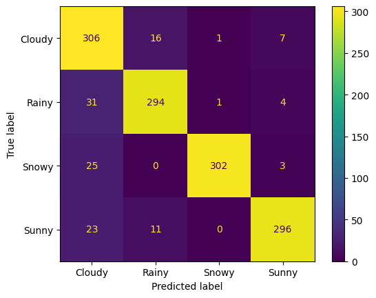

```
Model 2 Average Metrics:
Accuracy: 0.8992
Precision: 0.9053
Recall: 0.8992
F1-Score: 0.9007
```

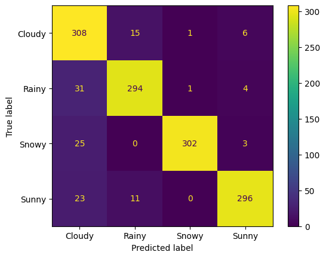

```
Model 3 Average Metrics:
Accuracy: 0.8992
Precision: 0.9055
Recall: 0.8992
F1-Score: 0.9007
```

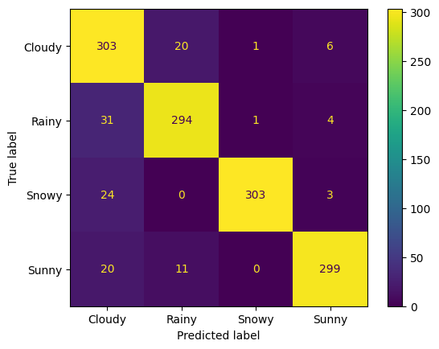

```python
# print average evaluation metrics
print("\nModel 1 Average Metrics:")
print(f"Accuracy: {np.mean(accuracy_scores_1):.4f}")
print(f"Precision: {np.mean(precision_scores_1):.4f}")
print(f"Recall: {np.mean(recall_scores_1):.4f}")
print(f"F1-Score: {np.mean(f1_scores_1):.4f}")

cm_display = metrics.ConfusionMatrixDisplay(confusion_matrix = confusion_matrix_1, display_labels = ['Cloudy', 'Rainy', 'Snowy', 'Sunny'])
cm_display.plot()
plt.show()

print("\nModel 2 Average Metrics:")
print(f"Accuracy: {np.mean(accuracy_scores_2):.4f}")
print(f"Precision: {np.mean(precision_scores_2):.4f}")
print(f"Recall: {np.mean(recall_scores_2):.4f}")
print(f"F1-Score: {np.mean(f1_scores_2):.4f}")

cm_display = metrics.ConfusionMatrixDisplay(confusion_matrix = confusion_matrix_2, display_labels = ['Cloudy', 'Rainy', 'Snowy', 'Sunny'])
cm_display.plot()
plt.show()

print("\nModel 3 Average Metrics:")
print(f"Accuracy: {np.mean(accuracy_scores_3):.4f}")
print(f"Precision: {np.mean(precision_scores_3):.4f}")
print(f"Recall: {np.mean(recall_scores_3):.4f}")
print(f"F1-Score: {np.mean(f1_scores_3):.4f}")

cm_display = metrics.ConfusionMatrixDisplay(confusion_matrix = confusion_matrix_3, display_labels = ['Cloudy', 'Rainy', 'Snowy', 'Sunny'])
cm_display.plot()
plt.show()
```

### Deep Layers

Investigate generalization performance by altering the number of layers in the deep branch of the network. Try at least two models (this “two” includes the wide and deep model trained from the previous step). Use the method of cross validation and evaluation metric that you argued for at the beginning of the lab to answer: What model with what number of layers performs superiorly? Use proper statistical methods to compare the performance of different models.

```python
# Let's create a model that's even deeper than the third one :)

# Model 4
hidden1_m4 = layers.Dense(256, activation='relu')(deep_input)
hidden2_m4 = layers.Dense(128, activation='relu')(hidden1_m4)
hidden3_m4 = layers.Dense(64, activation='relu')(hidden2_m4)
hidden4_m4 = layers.Dense(32, activation='relu')(hidden3_m4)
deep_output_4 = layers.Dense(4, activation='softmax', name="deep_output_4")(hidden4_m4)

# combine the wide and deep model
combined_output_4 = layers.concatenate([wide_output, deep_output_4])

# final output layer
output_4 = layers.Dense(4, activation='softmax', name="output_1")(combined_output_4)

# create model
model_4 = keras.Model(inputs=[wide_input, deep_input], outputs=output_4, name="wide_deep_4")

# compile models
model_4.compile(optimizer='adam', loss='categorical_crossentropy', metrics=['accuracy'])

# list to store evaluation metrics for the model across folds
accuracy_scores_4, precision_scores_4, recall_scores_4, f1_scores_4 = [], [], [], []
```

```python
# add the cross features from df_encoded to X
X[wide_input_features] = df_encoded[wide_input_features]

for fold, (train_index, test_index) in enumerate(SKFold.split(X, y_multiclass)):
    print(f"Fold {fold + 1}")

    # split data into training and testing sets
    X_train, X_test = X.iloc[train_index], X.iloc[test_index]

    # prepare y_train and y_test
    y_train, y_test = y.iloc[train_index], y.iloc[test_index]
    y_train_multiclass = np.argmax(y_train.values, axis=1)
    y_test_multiclass = np.argmax(y_test.values, axis=1)

    # Prepare wide and deep inputs for training
    X_train_wide = X_train[wide_input_features]
    X_train_deep = X_train[deep_input_features]
    X_test_wide = X_test[wide_input_features]
    X_test_deep = X_test[deep_input_features]

    # train model
    history_4 = model_4.fit(
        {"wide_input": X_train_wide, "deep_input": X_train_deep},
        y_train,
        epochs=10,
        batch_size=32,
        validation_split=0.2
    )

    # make predictions on the test set
    y_pred_4 = model_4.predict({"wide_input": X_test_wide, "deep_input": X_test_deep})

    # convert predictions to class labels
    y_pred_classes_4 = np.argmax(y_pred_1, axis=1)
    y_true_classes = np.argmax(y_test.values, axis=1)

    # calculate evaluation metrics for each model
    accuracy_scores_4.append(accuracy_score(y_true_classes, y_pred_classes_4))
    precision_scores_4.append(precision_score(y_true_classes, y_pred_classes_4, average='weighted'))
    recall_scores_4.append(recall_score(y_true_classes, y_pred_classes_4, average='weighted'))
    f1_scores_4.append(f1_score(y_true_classes, y_pred_classes_4, average='weighted'))
    confusion_matrix_4 = confusion_matrix(y_true_classes, y_pred_classes_4)
```

```
Fold 1
297/297 ━━━━━━━━━━━━━━━━━━━━ 3s 3ms/step - accuracy: 0.4046 - loss: 1.2079 - val_accuracy: 0.8510 - val_loss: 0.9303
297/297 ━━━━━━━━━━━━━━━━━━━━ 1s 3ms/step - accuracy: 0.8668 - loss: 0.8548 - val_accuracy: 0.8670 - val_loss: 0.7411
297/297 ━━━━━━━━━━━━━━━━━━━━ 1s 3ms/step - accuracy: 0.8879 - loss: 0.6706 - val_accuracy: 0.8931 - val_loss: 0.5951
297/297 ━━━━━━━━━━━━━━━━━━━━ 1s 3ms/step - accuracy: 0.9003 - loss: 0.5511 - val_accuracy: 0.8620 - val_loss: 0.5889
297/297 ━━━━━━━━━━━━━━━━━━━━ 1s 3ms/step - accuracy: 0.8717 - loss: 0.5414 - val_accuracy: 0.8927 - val_loss: 0.4936
297/297 ━━━━━━━━━━━━━━━━━━━━ 1s 3ms/step - accuracy: 0.8885 - loss: 0.4744 - val_accuracy: 0.8956 - val_loss: 0.4611
297/297 ━━━━━━━━━━━━━━━━━━━━ 1s 3ms/step - accuracy: 0.8775 - loss: 0.4790 - val_accuracy: 0.8784 - val_loss: 0.4876
297/297 ━━━━━━━━━━━━━━━━━━━━ 1s 4ms/step - accuracy: 0.8797 - loss: 0.4700 - val_accuracy: 0.8779 - val_loss: 0.4778
297/297 ━━━━━━━━━━━━━━━━━━━━ 1s 5ms/step - accuracy: 0.8837 - loss: 0.4439 - val_accuracy: 0.8956 - val_loss: 0.4331
297/297 ━━━━━━━━━━━━━━━━━━━━ 2s 5ms/step - accuracy: 0.9020 - loss: 0.3920 - val_accuracy: 0.8952 - val_loss: 0.4224
42/42 ━━━━━━━━━━━━━━━━━━━━ 0s 3ms/step
Fold 2
297/297 ━━━━━━━━━━━━━━━━━━━━ 1s 3ms/step - accuracy: 0.9006 - loss: 0.3951 - val_accuracy: 0.8847 - val_loss: 0.4307
297/297 ━━━━━━━━━━━━━━━━━━━━ 1s 3ms/step - accuracy: 0.8906 - loss: 0.4159 - val_accuracy: 0.8965 - val_loss: 0.4117
297/297 ━━━━━━━━━━━━━━━━━━━━ 1s 3ms/step - accuracy: 0.8971 - loss: 0.3957 - val_accuracy: 0.8910 - val_loss: 0.4221
297/297 ━━━━━━━━━━━━━━━━━━━━ 1s 3ms/step - accuracy: 0.8940 - loss: 0.3981 - val_accuracy: 0.8771 - val_loss: 0.4530
297/297 ━━━━━━━━━━━━━━━━━━━━ 1s 3ms/step - accuracy: 0.8837 - loss: 0.4211 - val_accuracy: 0.8712 - val_loss: 0.4621
297/297 ━━━━━━━━━━━━━━━━━━━━ 1s 3ms/step - accuracy: 0.8744 - loss: 0.4485 - val_accuracy: 0.8716 - val_loss: 0.4607
297/297 ━━━━━━━━━━━━━━━━━━━━ 1s 3ms/step - accuracy: 0.8757 - loss: 0.4394 - val_accuracy: 0.8721 - val_loss: 0.4588
297/297 ━━━━━━━━━━━━━━━━━━━━ 2s 4ms/step - accuracy: 0.8767 - loss: 0.4418 - val_accuracy: 0.8746 - val_loss: 0.4538
297/297 ━━━━━━━━━━━━━━━━━━━━ 3s 5ms/step - accuracy: 0.8816 - loss: 0.4204 - val_accuracy: 0.8885 - val_loss: 0.4350
297/297 ━━━━━━━━━━━━━━━━━━━━ 1s 3ms/step - accuracy: 0.8958 - loss: 0.3899 - val_accuracy: 0.8897 - val_loss: 0.4176
42/42 ━━━━━━━━━━━━━━━━━━━━ 0s 2ms/step
Fold 3
297/297 ━━━━━━━━━━━━━━━━━━━━ 1s 3ms/step - accuracy: 0.8856 - loss: 0.4144 - val_accuracy: 0.8817 - val_loss: 0.4367
297/297 ━━━━━━━━━━━━━━━━━━━━ 1s 3ms/step - accuracy: 0.8866 - loss: 0.4118 - val_accuracy: 0.8817 - val_loss: 0.4390
297/297 ━━━━━━━━━━━━━━━━━━━━ 1s 3ms/step - accuracy: 0.8844 - loss: 0.4241 - val_accuracy: 0.8817 - val_loss: 0.4384
297/297 ━━━━━━━━━━━━━━━━━━━━ 1s 3ms/step - accuracy: 0.8886 - loss: 0.4067 - val_accuracy: 0.8906 - val_loss: 0.4179
297/297 ━━━━━━━━━━━━━━━━━━━━ 1s 3ms/step - accuracy: 0.9008 - loss: 0.3842 - val_accuracy: 0.8939 - val_loss: 0.4085
297/297 ━━━━━━━━━━━━━━━━━━━━ 1s 3ms/step - accuracy: 0.8964 - loss: 0.3887 - val_accuracy: 0.8935 - val_loss: 0.4063
297/297 ━━━━━━━━━━━━━━━━━━━━ 1s 3ms/step - accuracy: 0.8975 - loss: 0.3857 - val_accuracy: 0.8889 - val_loss: 0.4171
297/297 ━━━━━━━━━━━━━━━━━━━━ 1s 3ms/step - accuracy: 0.8937 - loss: 0.3900 - val_accuracy: 0.8902 - val_loss: 0.4157
297/297 ━━━━━━━━━━━━━━━━━━━━ 2s 5ms/step - accuracy: 0.8599 - loss: 0.4686 - val_accuracy: 0.8923 - val_loss: 0.4123
297/297 ━━━━━━━━━━━━━━━━━━━━ 1s 4ms/step - accuracy: 0.8955 - loss: 0.3879 - val_accuracy: 0.8918 - val_loss: 0.4126
42/42 ━━━━━━━━━━━━━━━━━━━━ 0s 2ms/step
Fold 4
297/297 ━━━━━━━━━━━━━━━━━━━━ 1s 3ms/step - accuracy: 0.8936 - loss: 0.3972 - val_accuracy: 0.8965 - val_loss: 0.4010
297/297 ━━━━━━━━━━━━━━━━━━━━ 1s 3ms/step - accuracy: 0.8896 - loss: 0.4091 - val_accuracy: 0.8965 - val_loss: 0.4014
297/297 ━━━━━━━━━━━━━━━━━━━━ 1s 3ms/step - accuracy: 0.8901 - loss: 0.4043 - val_accuracy: 0.8935 - val_loss: 0.4100
```

[output cut: 65 more lines]

```
297/297 ━━━━━━━━━━━━━━━━━━━━ 1s 3ms/step - accuracy: 0.8570 - loss: 0.4593 - val_accuracy: 0.8535 - val_loss: 0.4870
297/297 ━━━━━━━━━━━━━━━━━━━━ 1s 3ms/step - accuracy: 0.8539 - loss: 0.4713 - val_accuracy: 0.8540 - val_loss: 0.4868
42/42 ━━━━━━━━━━━━━━━━━━━━ 0s 2ms/step
Fold 10
297/297 ━━━━━━━━━━━━━━━━━━━━ 1s 3ms/step - accuracy: 0.8529 - loss: 0.4714 - val_accuracy: 0.8485 - val_loss: 0.5037
297/297 ━━━━━━━━━━━━━━━━━━━━ 1s 3ms/step - accuracy: 0.8540 - loss: 0.4767 - val_accuracy: 0.8481 - val_loss: 0.5038
297/297 ━━━━━━━━━━━━━━━━━━━━ 2s 5ms/step - accuracy: 0.8562 - loss: 0.4707 - val_accuracy: 0.8476 - val_loss: 0.5045
297/297 ━━━━━━━━━━━━━━━━━━━━ 3s 5ms/step - accuracy: 0.8539 - loss: 0.4799 - val_accuracy: 0.8481 - val_loss: 0.5036
297/297 ━━━━━━━━━━━━━━━━━━━━ 1s 4ms/step - accuracy: 0.8566 - loss: 0.4675 - val_accuracy: 0.8476 - val_loss: 0.5036
297/297 ━━━━━━━━━━━━━━━━━━━━ 1s 3ms/step - accuracy: 0.8551 - loss: 0.4697 - val_accuracy: 0.8464 - val_loss: 0.5041
297/297 ━━━━━━━━━━━━━━━━━━━━ 1s 3ms/step - accuracy: 0.8549 - loss: 0.4686 - val_accuracy: 0.8472 - val_loss: 0.5038
297/297 ━━━━━━━━━━━━━━━━━━━━ 1s 3ms/step - accuracy: 0.8562 - loss: 0.4739 - val_accuracy: 0.8464 - val_loss: 0.5052
297/297 ━━━━━━━━━━━━━━━━━━━━ 1s 3ms/step - accuracy: 0.8564 - loss: 0.4665 - val_accuracy: 0.8464 - val_loss: 0.5051
297/297 ━━━━━━━━━━━━━━━━━━━━ 1s 3ms/step - accuracy: 0.8557 - loss: 0.4683 - val_accuracy: 0.8464 - val_loss: 0.5051
42/42 ━━━━━━━━━━━━━━━━━━━━ 0s 2ms/step
```

```
Model 4 Average Metrics:
Accuracy: 0.3135
Precision: 0.3142
Recall: 0.3135
F1-Score: 0.3131
```

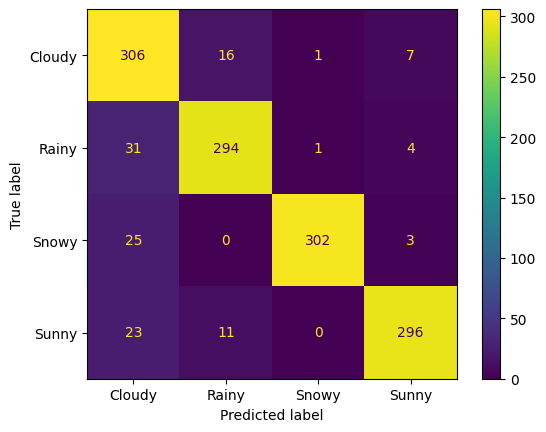

```python
# print average evaluation metrics
print("\nModel 4 Average Metrics:")
print(f"Accuracy: {np.mean(accuracy_scores_4):.4f}")
print(f"Precision: {np.mean(precision_scores_4):.4f}")
print(f"Recall: {np.mean(recall_scores_4):.4f}")
print(f"F1-Score: {np.mean(f1_scores_4):.4f}")

cm_display = metrics.ConfusionMatrixDisplay(confusion_matrix = confusion_matrix_4, display_labels = ['Cloudy', 'Rainy', 'Snowy', 'Sunny'])
cm_display.plot()
plt.show()
```

Let's compare the 1st model to the 4th model (the least and most deep) and analyze the performances.

The null hypothosis is that the two models perform the same, while the alternative hypothosis is that model 1 performs *better* than model 4. It is the same null and alternative for Precision, Recall, and F1-Score.

Note: Even though our chosen metric was Precision, it can still be helpful to view the others as well. If Precision's p-value is different than the others, we will choose to follow it.

```python
from scipy import stats

# comparing model_1 and model_4 using Precision
t_statistic, p_value = stats.ttest_rel(precision_scores_1, precision_scores_4, alternative = 'greater')

print("T-statistic for Precision:", t_statistic)
print("P-value for Precision::", p_value)

# comparing model_1 and model_4 using Recall
t_statistic, p_value = stats.ttest_rel(recall_scores_1, recall_scores_4, alternative = 'greater')

print("T-statistic for Recall:", t_statistic)
print("P-value for Recall::", p_value)

# comparing model_1 and model_4 using F1-scores
t_statistic, p_value = stats.ttest_rel(f1_scores_1, f1_scores_4, alternative = 'greater')

print("T-statistic for F1_scores:", t_statistic)
print("P-value for F1_scores::", p_value)
```

```
T-statistic for Precision: 8.956748782192703
P-value for Precision:: 4.440542566301614e-06
T-statistic for Recall: 8.95351725091326
P-value for Recall:: 4.453658638412416e-06
T-statistic for F1_scores: 8.955045232395612
P-value for F1_scores:: 4.447451595080437e-06
```

Now let's compare models 1 and 2, which are much closer, to see if their seemingly small differences actually have a big impact.

The null hypothosis is that the two models perform the same, while the alternative hypothosis is that model 1 performs *better* than model 2. It is the same null and alternative for Precision, Recall, and F1-Score.

Note: Even though our chosen metric was Precision, it can still be helpful to view the others as well. If Precision's p-value is different than the others, we will choose to follow it.

```python
# comparing model_1 and model_2 using Precision
t_statistic, p_value = stats.ttest_rel(precision_scores_1, precision_scores_2, alternative = 'greater')

print("T-statistic for Precision:", t_statistic)
print("P-value for Precision::", p_value)

# comparing model_1 and model_2 using Recall
t_statistic, p_value = stats.ttest_rel(recall_scores_1, recall_scores_2, alternative = 'greater')

print("T-statistic for Recall:", t_statistic)
print("P-value for Recall::", p_value)

# comparing model_1 and model_2 using F1-scores
t_statistic, p_value = stats.ttest_rel(f1_scores_1, f1_scores_2, alternative = 'greater')

print("T-statistic for F1_scores:", t_statistic)
print("P-value for F1_scores::", p_value)
```

```
T-statistic for Precision: -0.967283874044653
P-value for Precision:: 0.8206626613602344
T-statistic for Recall: -1.4664387058026347
P-value for Recall:: 0.9117108369082623
T-statistic for F1_scores: -1.413379132330356
P-value for F1_scores:: 0.904407661558982
```

### MLP Comparison

Compare the performance of your best wide and deep network to a standard multi-layer perceptron (MLP). Alternatively, you can compare to a network without the wide branch (i.e., just the deep network). For classification tasks, compare using the receiver operating characteristic and area under the curve. For regression tasks, use Bland-Altman plots and residual variance calculations. Use proper statistical methods to compare the performance of different models.

```python
# Import Necessary Libraries
from sklearn.neural_network import MLPClassifier
from sklearn.metrics import accuracy_score, classification_report, confusion_matrix
```

```python
y_train.head()
```

|  | Weather Type_Cloudy | Weather Type_Rainy | Weather Type_Snowy | Weather Type_Sunny |
| --- | --- | --- | --- | --- |
| 0 | False | True | False | False |
| 1 | True | False | False | False |
| 2 | False | False | False | True |
| 3 | False | False | False | True |
| 4 | False | True | False | False |

```python
# Make Classifier
MLPModel = MLPClassifier(random_state=42)
MLPModel.fit(X_train, y_train)
```

```
MLPClassifier(random_state=42)
```

```python
# Get Predictions
y_pred = MLPModel.predict(X_test)

# Generate a classification report
class_report = classification_report(y_test, y_pred)
print("Classification Report:", class_report)
```

```
Classification Report:               precision    recall  f1-score   support

           0       0.79      0.88      0.83       330
           1       0.91      0.88      0.89       330
           2       0.97      0.92      0.95       330
           3       0.98      0.75      0.85       330

   micro avg       0.90      0.86      0.88      1320
   macro avg       0.91      0.86      0.88      1320
weighted avg       0.91      0.86      0.88      1320
 samples avg       0.85      0.86      0.85      1320
```

```python
Total = 0
for i in precision_scores_1:
  Total = Total + i
DeepModel_Precision_Score = Total/10
print("Deep Learning Percision Score:",DeepModel_Precision_Score)

MLP_Precision_Score = (.79+.91+.97+.98)/4
print("Multi-Layer Percision Score:",MLP_Precision_Score)

Total = 0
for i in recall_scores_1:
  Total = Total + i
DeepModel_Recall_Score = Total/10
print("Deep Learning Recall Score:",DeepModel_Recall_Score)

MLP_Recall_Score = (.88+.88+.92+.75)/4
print("Multi-Layer Recall Score:",MLP_Recall_Score)

Total = 0
for i in f1_scores_1:
  Total = Total + i
DeepModel_F1Score_Score = Total/10
print("Deep Learning F1 Score:",DeepModel_F1Score_Score)

MLP_F1Score_Score = (.83+.89+.95+.85)/4
print("Multi-Layer F1 Score:",MLP_F1Score_Score)
```

```
Deep Learning Percision Score: 0.9044051032955462
Multi-Layer Percision Score: 0.9125
Deep Learning Recall Score: 0.8978787878787878
Multi-Layer Recall Score: 0.8575
Deep Learning F1 Score: 0.8993805080844604
Multi-Layer F1 Score: 0.88
```

After doing some research, it appears that the curve evaluation is for binary classification tasks. We searched through both the scikit learn documentation and several articles for how to calculate these metric, and none of them seemed to make sense for a multilayer perceptron.

# Download in HTML

```python
### THIS IS TO TURN NOTEBOOK INTO HTML FORMAT AND DOWNLOAD:

from google.colab import files
uploaded_files = files.upload()

# Convert ipynb to html
import subprocess
notebook_filename = list(uploaded_files.keys())[0]
subprocess.run(["pip", "install", "nbconvert"])
subprocess.run(["jupyter", "nbconvert", notebook_filename, "--to", "html"])

# Download the html version
html_filename = notebook_filename[:-6] + ".html" # correct the slicing to avoid error
files.download(html_filename)
```

```
Saving Weather_Classification_using_Wide_and_Deep_Neural_Networks.ipynb to Weather_Classification_using_Wide_and_Deep_Neural_Networks.ipynb
```